# Your Digest for Monday, Sep 18, 2023 11:59 PM

## Comparison of malaria species

[figure not shown]

"merozoite" - "Meros" means "part" or "segment," while "zoion" translates to "animal"

**Bone marrow infection:**

> [!TIP] The two organisms causing the most severe forms of disease infect bone marrow.
- Falciparum has been shown to infect bone marrow, specially in the immature gametocyte stage. [Source](https://malariajournal.biomedcentral.com/articles/10.1186/s12936-021-03792-1)
- Newer articles state that vivax also infects bone marrow. [Source](https://journals.asm.org/doi/10.1128/mbio.00625-18)  
  **Vertical tranmission**:  
  #2021BSQ-JUL Q08
- All species of malaria can be transmitted in utero.
- Most commonly with Falciparum and vivax.
- Falciparum is well known to cause transplacental transmission. The parasite can be found in intervillous spaces of the placenta.(placental infection) This causes placental inflammation and various placental abnormalities resulting in IUGR, premature delivery, low birth weight.[Source](https://www.frontiersin.org/articles/10.3389/fmicb.2021.777343/full)  
  Falciparum infection of RBC -> RBC produces **sticky knobs of proteins** -> RBC adhere to capillary endothelim -> sequestration -> partial blood flow obstruction -> compliactions like cerebral malaria and renal failure.

> [!INFO] Summary
> - Uncomplicated non falciparum malaria
>   - Treatment is directed at the erythrocytic forms.
>   - If species unknown of patient develops severe malaria -> treat as for falciparum.
>   - If chloroquine sensitive, give chloroquine or ACT.
>   - If chloroquine resistant, give ACT.
>   - Fever and parasitaemia stellet in 2 - 4 days.
>   - Antirelapse therapy with primaquine is started when symptoms begin to resolve.
> - Treatment of severe malaria:
>   - If no ACT resistance, give IV artesunate.
>   - If ACT resistance is prevalent (south east asia) -> combine IV **quinine** with IV ACT.

#### Treatment of malaria in #pregnancy

ACT is safe in pregnancy  
Chloloquine is safe in pregnancy.  
Primaquine is problematic because it exacerbates G6PD-deficiency anaemia;

- Therefore, it's **contraindicated in pregnancy** as the G6PD status of the foetus is unknown.
- Although breast milk concentrations are low, it's not given while the mother is breastfeeding *if the infant is found to be G6PD deficient*.
- In the above cases, *chloroquine* is continued until the baby is delivered or until cessation of breast feeding.

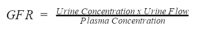

[[Nephrology miscellaneous#Facts about renal blood flow]]

# Renal blood flow

## Facts about renal blood flow:

[Source](https://derangedphysiology.com/main/cicm-primary-exam/required-reading/cardiovascular-system/Chapter%20477/renal-blood-flow)

- Renal arteries are end arteries. [[whatIsAnEndArtery.png]]
- There is a high pressure capillary bed (glomerular) and low pressure capillary bed (peritubular).
- 95% of renal blood flow goes to the cortex! only 5% to the medulla. Renal blood flow is high not because of metabolic demand but because it's needed for filtration.

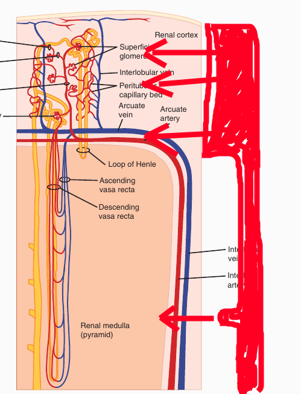

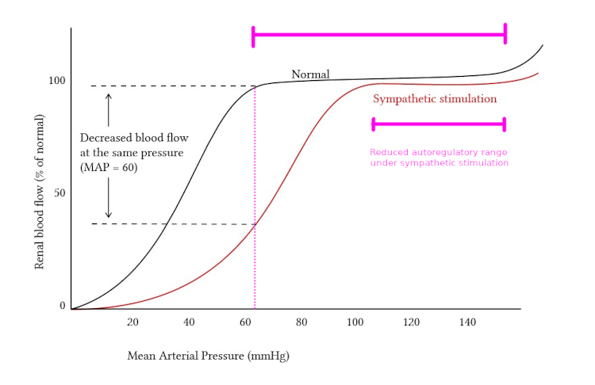

- Factors decreasing renal blood flow
  - Noradrenaline - decreases renal blood flow.
  - Adrenaline -> increased resistance and **decreased** renal blood flow.
  - Angiotensin II- Efferent > afferent constriction
  - Endothelin
- Factors increasing renal blood flow
  - Dopamine - increases renal blood flow.
  - Prostaglandins -> increase blood flow in the cortex.
  - Bradykinin
  - Acetylcholine - renal vasodilation
  - Blood glucose
  - High protein diet (and amino acids) -> increases renal blood flow.
  - Atrial and brain natriuretic peptide (ANP and BNP) decrease arteriolar resistance and increase renal blood flow [Source](https://www.osmosis.org/learn/Regulation_of_renal_blood_flow)

[output not shown]

- Nicorandil  
  3. Can cause QT prolongation. [Source](https://www.sciencedirect.com/science/article/pii/S1875213611002713)
  1. Proably has mortality benefit : [Source](https://www.sciencedirect.com/science/article/pii/S1875213611002713) (IONA study)
  2. Potassium channel activators dilate arterial smooth muscle.
  3. Nicorandil has nitrate groups as well so it also dilates veins.
  4. So arterial and venodilation exerts an antianginal effect.
  5. Side effects: headache

**80%** have right dominant circulation where the RCA turns toward the apex on the posterior aspect of the heart.  
About 20% : codominant  
Aabotu 10% : left dominant  
(yes they don't add up to 100%)[Source](https://www.ncbi.nlm.nih.gov/books/NBK534790/)

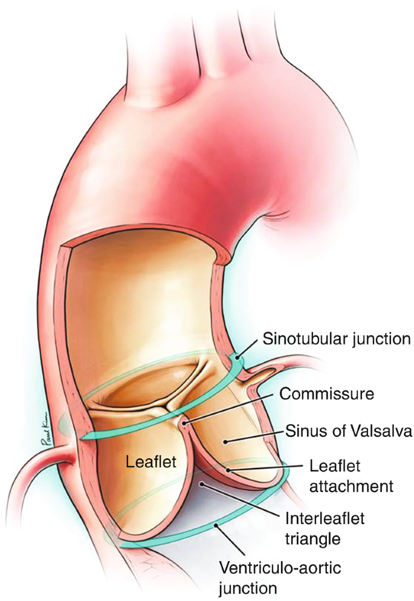

#2021BSQ-JUL Q14  
Sinuses of valsalva / aortic sinuses are the spaced between the valves and the wall.

- **Left anterior descending** artery supplies and *anterior 2/3 of the interventricular septum*.
  - the LAD also supplies most of the *right and left bundle branches*.
  - LAD also supplies the *anterior papillary muscle* of the bicuspid valve.
  - LAD provides *collateral circulation* to the anterior right ventricle, posterior part of the interventricular septum and posterior descending artery.
- **Left conus artery** - supplies the outflow tract of the right ventricle and a large part of the anterior free wall of the *right ventricle*;